# California Housing Prices - Project for the course Data programming 2021/22

Sebastijan Peruško, 89191059 FAMNIT

2022-06-17

## Introduction

In this project we will analyse the dataset “California Housing Prices Data”, published by user FEDESORIANO on Kraggle([FEDESORIANO 2022](https://www.studenti.famnit.upr.si/~89191059/PP/Project/ProjectCaliforniaHousingPricesSebastijanPerusko.html#ref-CaliforniaHousingPrices2022)). This dataset is derived and modified version of the California Housing Data used in the paper “Sparse spatial autoregressions” of Pace K. and others ([Pace and Barry 1997](https://www.studenti.famnit.upr.si/~89191059/PP/Project/ProjectCaliforniaHousingPricesSebastijanPerusko.html#ref-RePEc)). The original dataset was created during the 1990 California census and represents the basic data and proprieties about house within predetermined block in the state of California.

## Presentation and description of the problem

The objective of the project is to analyse the data to understand which factors contribute to the price and valuation of a house. Although the dataset is old, it can be used to represent certain characteristics that lead to a higher or lower price of a house also nowadays.

The research question(RQ) that we are going to answer in this project are the following:

- (RQ1) What are the main features that are related to the median house price within a block?
- (RQ2) Which cities and countries have the highest median household price within a block? And in which is it lowest?
- (RQ3) Is the proximity to the coast correlated with the median price of the houses?

## Presentation of the data

The dataset contains 14 columns representing the properties of 20,600 residential blocks in California of the 1990 census. The original data was formed by the first 9 columns, the remaining were added by the publisher of this dataset on Kaggle. Specifically, the columns are as follows:

- Median House Value: Median house value for households within a block (measured in US Dollars)
- Median Income: Median income for households within a block of houses (measured in tens of thousands of US Dollars) [10k$]
- Median Age: Median age of a house within a block; a lower number is a newer building [years]
- Total Rooms: Total number of rooms within a block
- Total Bedrooms: Total number of bedrooms within a block
- Population: Total number of people residing within a block
- Households: Total number of households, a group of people residing within a home unit, for a block
- Latitude: A measure of how far north a house is; a higher value is farther north in degrees.
- Longitude: A measure of how far west a house is; a higher value is farther west in degrees.
- Distance to coast: Distance to the nearest coast point in meters.
- Distance to Los Angeles: Distance to the centre of Los Angeles in meters.
- Distance to San Diego: Distance to the centre of San Diego in meters.
- Distance to San Jose: Distance to the centre of San Jose in meters.
- Distance to San Francisco: Distance to the centre of San Francisco in meters.

In the following chuck we can observe a summary of the data, and also the type of each of the columns.

```r
read.csv("Data/California_Houses.csv")->dfHousePrice

sapply(colnames(dfHousePrice), \(x){class(dfHousePrice%>%.[, x])})
```

```
##       Median_House_Value            Median_Income               Median_Age
##                "numeric"                "numeric"                "integer"
##                Tot_Rooms             Tot_Bedrooms               Population
##                "integer"                "integer"                "integer"
##               Households                 Latitude                Longitude
##                "integer"                "numeric"                "numeric"
##        Distance_to_coast           Distance_to_LA     Distance_to_SanDiego
##                "numeric"                "numeric"                "numeric"
##      Distance_to_SanJose Distance_to_SanFrancisco
##                "numeric"                "numeric"
```

```r
summary(dfHousePrice)
```

```
##  Median_House_Value Median_Income       Median_Age      Tot_Rooms
##  Min.   : 14999     Min.   : 0.4999   Min.   : 1.00   Min.   :    2
##  1st Qu.:119600     1st Qu.: 2.5634   1st Qu.:18.00   1st Qu.: 1448
##  Median :179700     Median : 3.5348   Median :29.00   Median : 2127
##  Mean   :206856     Mean   : 3.8707   Mean   :28.64   Mean   : 2636
##  3rd Qu.:264725     3rd Qu.: 4.7432   3rd Qu.:37.00   3rd Qu.: 3148
##  Max.   :500001     Max.   :15.0001   Max.   :52.00   Max.   :39320
##   Tot_Bedrooms      Population      Households        Latitude
##  Min.   :   1.0   Min.   :    3   Min.   :   1.0   Min.   :32.54
##  1st Qu.: 295.0   1st Qu.:  787   1st Qu.: 280.0   1st Qu.:33.93
##  Median : 435.0   Median : 1166   Median : 409.0   Median :34.26
##  Mean   : 537.9   Mean   : 1425   Mean   : 499.5   Mean   :35.63
##  3rd Qu.: 647.0   3rd Qu.: 1725   3rd Qu.: 605.0   3rd Qu.:37.71
##  Max.   :6445.0   Max.   :35682   Max.   :6082.0   Max.   :41.95
##    Longitude      Distance_to_coast  Distance_to_LA      Distance_to_SanDiego
##  Min.   :-124.3   Min.   :   120.7   Min.   :    420.6   Min.   :    484.9
##  1st Qu.:-121.8   1st Qu.:  9079.8   1st Qu.:  32111.3   1st Qu.: 159426.4
##  Median :-118.5   Median : 20522.0   Median : 173667.5   Median : 214739.8
##  Mean   :-119.6   Mean   : 40509.3   Mean   : 269422.0   Mean   : 398164.9
##  3rd Qu.:-118.0   3rd Qu.: 49830.4   3rd Qu.: 527156.2   3rd Qu.: 705795.4
##  Max.   :-114.3   Max.   :333804.7   Max.   :1018260.1   Max.   :1196919.3
##  Distance_to_SanJose Distance_to_SanFrancisco
##  Min.   :   569.4    Min.   :   456.1
##  1st Qu.:113119.9    1st Qu.:117395.5
##  Median :459758.9    Median :526546.7
##  Mean   :349187.6    Mean   :386688.4
##  3rd Qu.:516946.5    3rd Qu.:584552.0
##  Max.   :836762.7    Max.   :903627.7
```

```r
dfHousePrice%>%
  head(5)%>%
  DT::datatable(options = list(scrollX = TRUE))
```

|  | Median_House_Value | Median_Income | Median_Age | Tot_Rooms | Tot_Bedrooms | Population | Households | Latitude | Longitude | Distance_to_coast | Distance_to_LA | Distance_to_SanDiego | Distance_to_SanJose | Distance_to_SanFrancisco |
| --- | --- | --- | --- | --- | --- | --- | --- | --- | --- | --- | --- | --- | --- | --- |
| 1 | 452600 | 8.3252 | 41 | 880 | 129 | 322 | 126 | 37.88 | -122.23 | 9263.04077285038 | 556529.1583418 | 735501.80698384 | 67432.5170008434 | 21250.2137667799 |
| 2 | 358500 | 8.3014 | 21 | 7099 | 1106 | 2401 | 1138 | 37.86 | -122.22 | 10225.7330715424 | 554279.850068765 | 733236.884360166 | 65049.9085739663 | 20880.6003997074 |
| 3 | 352100 | 7.2574 | 52 | 1467 | 190 | 496 | 177 | 37.85 | -122.24 | 8259.08510932293 | 554610.717069378 | 733525.68293736 | 64867.2898334847 | 18811.4874496884 |
| 4 | 341300 | 5.6431 | 52 | 1274 | 235 | 558 | 219 | 37.85 | -122.25 | 7768.0865708364 | 555194.266086292 | 734095.290744033 | 65287.1384120522 | 18031.0475677266 |
| 5 | 342200 | 3.8462 | 52 | 1627 | 280 | 565 | 259 | 37.85 | -122.25 | 7768.0865708364 | 555194.266086292 | 734095.290744033 | 65287.1384120522 | 18031.0475677266 |

Another dataset that we are going to use is the “California cities dataset” published by the user CAM NUGENT ([NUGENT 2019](https://www.studenti.famnit.upr.si/~89191059/PP/Project/ProjectCaliforniaHousingPricesSebastijanPerusko.html#ref-CaliforniaCitiesDataset2022)). This dataset contains multiple CSV files containing information about cities and counties inside the California state with the respectively population from 1980, 1990, 2000 and 2010. The CSV “cal_populations_county.csv” contains the following columns:

- Country: All the countries of the state of California.
- City: All the cities and town of the state of California.
- Incorportation_date: The incorportation date or the formation of a new city from township territory for each city or twon in the satte of Calfornia.
- pop_april_1980: The population of a determined city in the state of Calfiornia in the year 1980
- pop_april_1990: The population of a determined city in the state of Calfiornia in the year 1990
- pop_april_2000: The population of a determined city in the state of Calfiornia in the year 2000
- pop_april_2010: The population of a determined city in the state of Calfiornia in the year 2010

In the following we can observe the type of the columns and the head of the dataframe.

```r
read.csv("Data/cal_populations_county.csv")->dfCityCountry


sapply(colnames(dfCityCountry), \(x){class(dfCityCountry%>%.[, x])})
```

```
##              County                City Incorportation_date      pop_april_1980
##         "character"         "character"         "character"           "integer"
##      pop_april_1990      pop_april_2000      pop_april_2010
##           "integer"           "integer"           "integer"
```

```r
dfCityCountry%>%
  head()%>%
  DT::datatable(options = list(scrollX = TRUE))
```

|  | County | City | Incorportation_date | pop_april_1980 | pop_april_1990 | pop_april_2000 | pop_april_2010 |
| --- | --- | --- | --- | --- | --- | --- | --- |
| 1 | San Bernardino | Adelanto | 1970 | 2164 | 8517 | 18130 | 31765 |
| 2 | Los Angeles | Agoura Hills | 1982 |  | 20390 | 20537 | 20330 |
| 3 | Alameda | Alameda | 1854 | 63852 | 76459 | 72259 | 73812 |
| 4 | Alameda | Albany | 1908 | 15130 | 16327 | 16444 | 18539 |
| 5 | Los Angeles | Alhambra | 1903 | 64767 | 82106 | 85804 | 83089 |
| 6 | Modoc | Alturas | 1901 | 3025 | 3231 | 2892 | 2827 |

Finnaly, the last dataset will be from the same dataset as above([NUGENT 2019](https://www.studenti.famnit.upr.si/~89191059/PP/Project/ProjectCaliforniaHousingPricesSebastijanPerusko.html#ref-CaliforniaCitiesDataset2022)), and is called “cal_cities_lat_long.csv”. This dataset contain only 3 columns that are:

- Name: City or town in the state of California.
- Latitude: Latitude of the city or town of the state of California.
- Longitude: Longitude of the city or town in the state of California.

Also if our primary dataset contains the data about longitude and latitude of the households, in our case we wanted to use it because of the exact representation of the center of a determined city.

In the following we can observe the type of the columns and the head of the dataframe.

```r
read.csv("Data/cal_cities_lat_long.csv")->LatLongCities


sapply(colnames(LatLongCities), \(x){class(LatLongCities%>%.[, x])})
```

```
##        Name    Latitude   Longitude
## "character"   "numeric"   "numeric"
```

```r
LatLongCities%>%
  head()%>%
  DT::datatable(options = list(scrollX = TRUE))
```

|  | Name | Latitude | Longitude |
| --- | --- | --- | --- |
| 1 | Adelanto | 34.582769 | -117.409214 |
| 2 | Agoura Hills | 34.153339 | -118.761675 |
| 3 | Alameda | 37.765206 | -122.241636 |
| 4 | Albany | 37.886869 | -122.297747 |
| 5 | Alhambra | 34.095286 | -118.127014 |
| 6 | Aliso Viejo | 33.575 | -117.725556 |

## Exploratory data analysis

In this section, we analyse the data obtained. The analysis will be divided into sections describing the modelling of the data from the initial to the final stage.

### Source of the data

Given that we have in our data the longitude and latitude of the household within a block, we can create a map, representing in which part of California the data was acquired. Like we can see, the map is reassemble the shape of the Californian state, and this allow us to conclude that the data expand through entire state of California. Another observation, is that the points are more dense within the big cities of California, namely, San Francisco, San Jose, Los Angeles and San Diego.

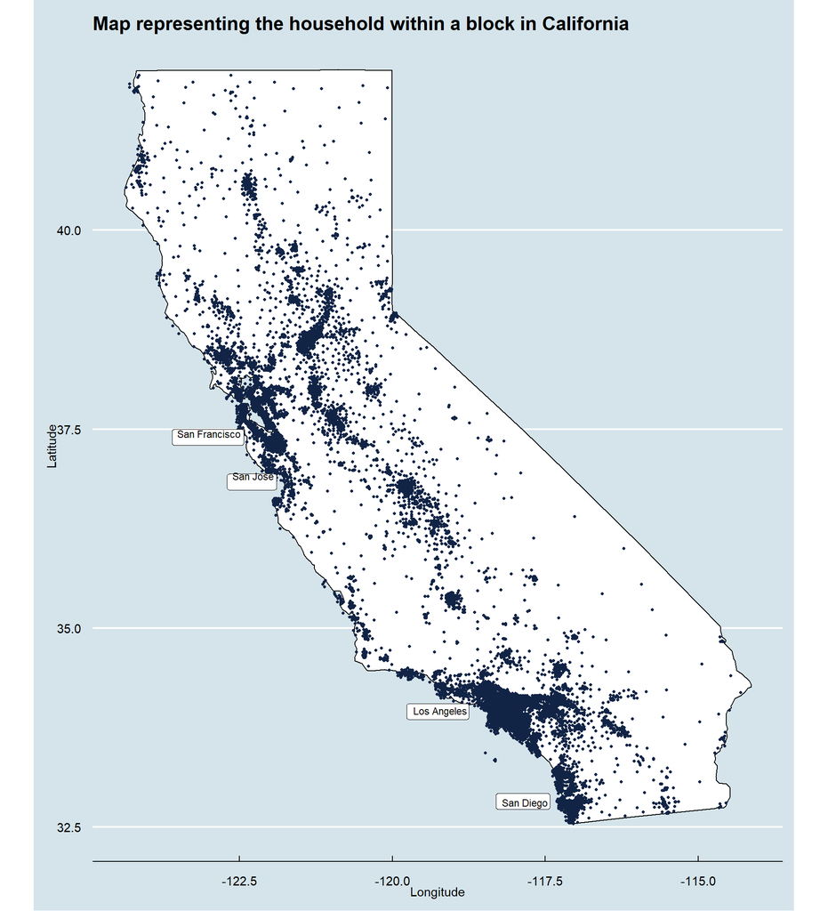

```r
states <- map_data("state")
west_coast <- subset(states, region %in% c("california"))

ggplot() +
  geom_polygon(data=west_coast,aes(x = long, y = lat, group = group), fill = "white", color = "black") +
  geom_point(data=dfHousePrice, aes(x = Longitude, y = Latitude), shape = "bullet", size = 1.5, colour = "#112446")+
  labs(data=dfHousePrice,
    x = "Longitude",
    y = "Latitude",
    title = "Map representing the household within a block in California"
  )+
  coord_fixed(1.3)+
  geom_label(data=dfHousePrice%>%filter(Latitude==37.7 & Longitude==-122.43),aes(Longitude, Latitude, label="San Francisco"),vjust = 2, hjust=1, size=3)+
  geom_label(data=dfHousePrice%>%filter(Latitude==37.34 & Longitude==-121.89),aes(Longitude, Latitude, label="San Jose"),vjust = 3, hjust=1, size=3)+
  geom_label(data=dfHousePrice%>%filter(Latitude==32.72 & Longitude==-117.16),aes(Longitude, Latitude, label="San Diego"),vjust = 0, hjust=1.3, size=3)+
  geom_label(data=dfHousePrice%>%filter(Latitude==34.05 & Longitude==-118.24),aes(Longitude, Latitude, label="Los Angeles"),vjust = 1, hjust=1.5, size=3)+
  ggthemes::theme_economist()
```

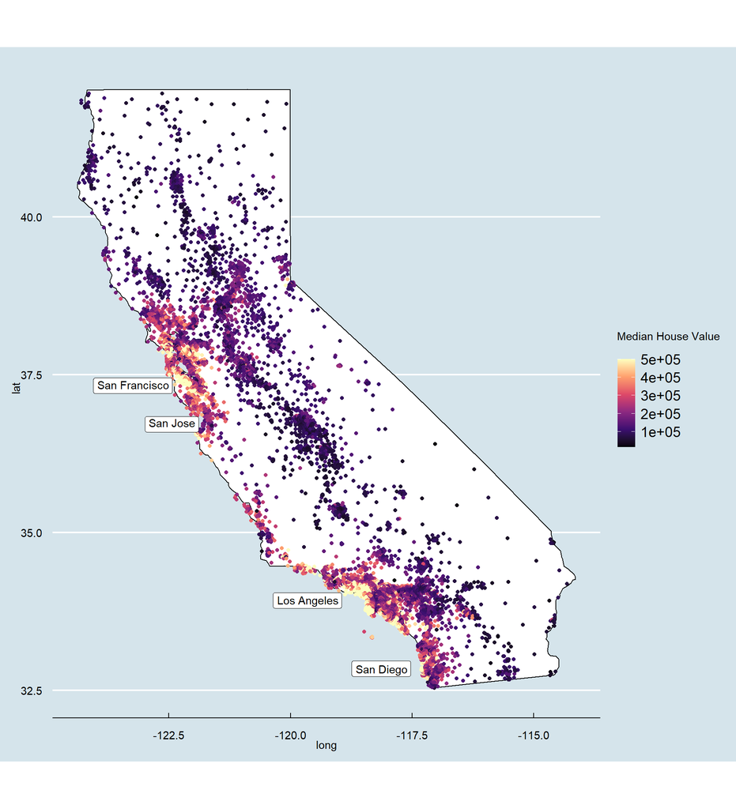

```r
ggplot(dfHousePrice) +
  geom_polygon(data=west_coast,aes(x = long, y = lat, group = group), fill = "white", color = "black") +
  geom_point(data=dfHousePrice, aes(x = Longitude, y = Latitude, colour = Median_House_Value), shape = "circle", size = 1.5)+
  scale_color_viridis_c(option = "magma", direction = 1) +
  coord_fixed(1.3)+
  geom_label(data=dfHousePrice%>%filter(Latitude==37.7 & Longitude==-122.43),aes(Longitude, Latitude, label="San Francisco"),vjust = 2, hjust=1)+
  geom_label(data=dfHousePrice%>%filter(Latitude==37.34 & Longitude==-121.89),aes(Longitude, Latitude, label="San Jose"),vjust = 3, hjust=1)+
  geom_label(data=dfHousePrice%>%filter(Latitude==32.72 & Longitude==-117.16),aes(Longitude, Latitude, label="San Diego"),vjust = 0, hjust=1.3)+
  geom_label(data=dfHousePrice%>%filter(Latitude==34.05 & Longitude==-118.24),aes(Longitude, Latitude, label="Los Angeles"),vjust = 1, hjust=1.5)+
  ggthemes::theme_economist()+
  theme(legend.position="right")+
  labs(color = "Median House Value\n") +
  scale_x_continuous(labels = scales::comma)
```

### Linear correlation of the data

```r
dfHousePrice%>%
  mutate(num_room_household = Tot_Rooms/Households,
         num_bedrooms_household = Tot_Bedrooms/Households,
         num_population_household = Population/Households)->dfHouseAddFeatures
```

Based on all the columns we have, we will now analyze these data using Pearson’s correlation. Pearson’s correlation allows us to understand the linear correlation between two sets of numbers and moves in the range from -1, which means maximum negative correlation, to 1, which means maximum positive correlation. On the other hand, the closer we get to 0, the less correlation we have.

To check the correlation between all this columns we can plot a heat map representing the Pearson correlation between all of this features.

In the following heatmap, we will dwell on the Pearson correlation between the median house value and the other columns. The median income represents the column that is most positively correlated with the median house value. This means that a higher median income is correlated with a higher median house value, so a person who has a higher income also has a higher house value. We can see, that also the new added column, namely, the number of rooms per household is also correlated with the median value of a house in block. Obviously, this column is quite less correlated, with a correlation coefficient of 0.15. On the other hand, the most negatively correlated value is distance from the coast. In fact, less distance from the coast is correlated with a higher value. This can also be influenced by California’s major oceanfront cities.

Another observation from the heat map are some obvious correlation, like the correlation between total number of room, total number of bedrooms and population. Thus, this mean, that a greater number of rooms is also correlated with a greater number of bedroom and a greater number of population and vice versa. We can see also a great positive and negative correlation manifest itself into the top right corner with the considered geographical distances.

Moving to the most interesting correlation we can dwell on the median age, we can observe that the median age of a house within a block is negatively correlated with the total number of rooms, total number of bedrooms, population and household within a block. Another observation is that the median age is also negatively correlated with the distance to coast.

Finnaly, we can dwell on the median income and see that there is a solid correlation between the number of rooms per household and the median income. Thus, people that earn more tend to have also more rooms in the house. Another observation is that there is a negative correlation with the distance to coast.

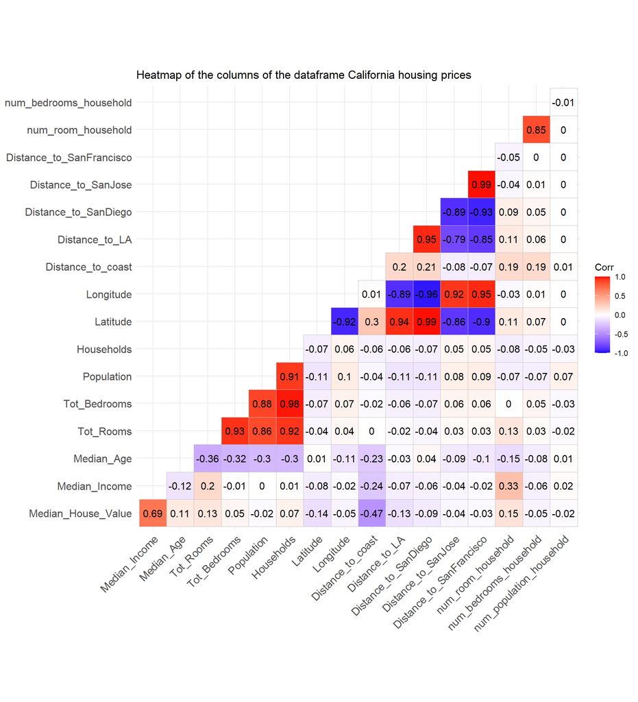

```r
corerlationHouseMediaValue <- cor(dfHouseAddFeatures, method="pearson")

ggcorrplot(corerlationHouseMediaValue, lab = TRUE, type = "lower", title="Heatmap of the columns of the dataframe California housing prices")
```

Now we will focus on the scatter plots, that can help us to identify linear relationship between the x-axis and y-axis. The following plot show the scatter plots between a selected number of columns, that were choose based on the upper heatmap.

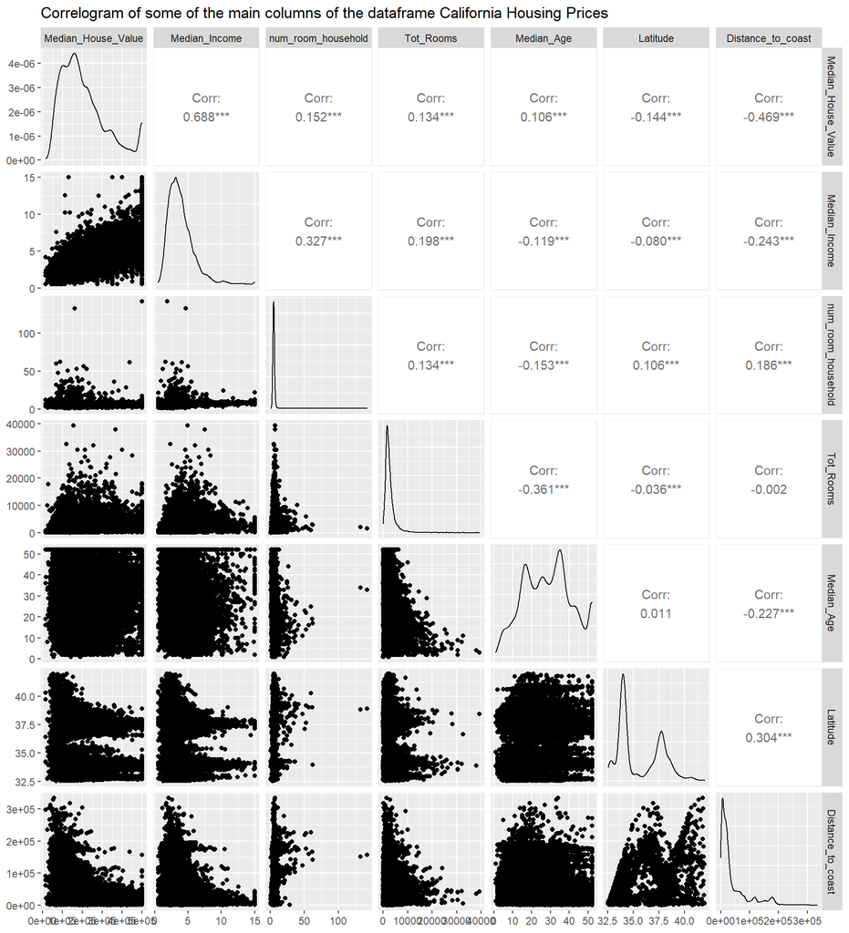

```r
dfHouseAddFeatures%>%select(Median_House_Value ,
                            Median_Income,
                            num_room_household,
                            Tot_Rooms, Median_Age,
                            Latitude,
                            Distance_to_coast)->dfscatterSelect


ggpairs(dfscatterSelect, title="Correlogram of some of the main columns of the dataframe California Housing Prices")
```

One of the most interesting part of this scatterplot matrix is the scatterplot between median house value and median income and the distribution of the median income. Regarding the latter, we can see that it follows the right-skewed distribution. The median income is measured in tens of thousands of US Dollars, so we can see that the population that reside in the California state in the 90s had an income of 38,700 US dollars in mean and 35,348 US dollars in median.

```r
dfHouseAddFeatures%>%
  summarize(mean=mean(.$Median_Income), median=median(.$Median_Income))
```

```
##       mean median
## 1 3.870671 3.5348
```

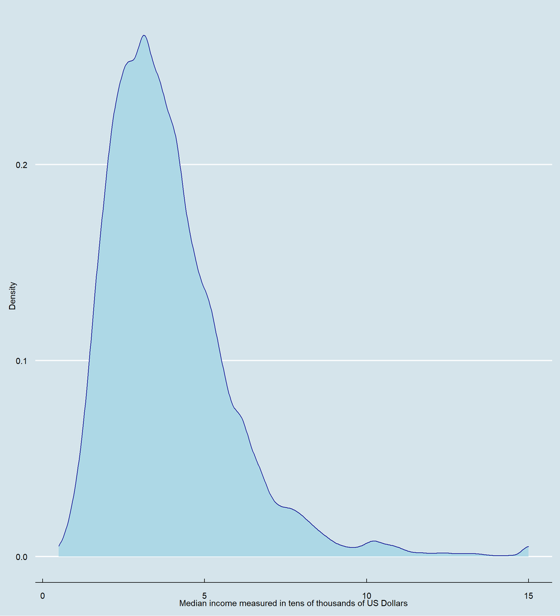

```r
ggplot(data=dfHouseAddFeatures,
       aes(x=dfHouseAddFeatures$Median_Income))+
  geom_density(color="darkblue", fill="lightblue")+
  ggthemes::theme_economist()+
  xlab("Median income measured in tens of thousands of US Dollars")+
  ylab("Density")
```

In the following scatter plot, we can observe the how the median house value is linearly correlated with the median income. This mean, that the median income a quite solid indicator of the median price of household, and we can also try to build a linear regression model where this feature will be one of the main.

One observation regarding this plot, is that on the right we can see a vertical line. The presence of this line is due to the fact, that the maximum value of the house was 500,000 US dollars, and every house within a block more expensive than this received this value. In the case we build a linear regression model, we should remove this value to avoid to compromising the model.

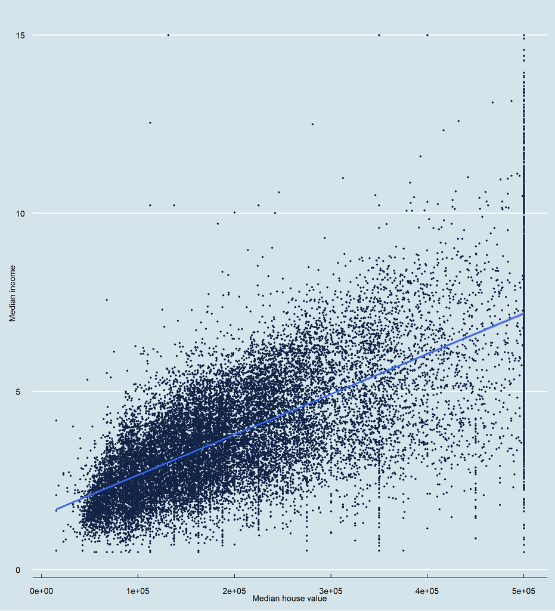

```r
ggplot(dfHouseAddFeatures) +
  aes(x = Median_House_Value, y = Median_Income) +
  geom_point(shape = "bullet", size = 1.5, colour = "#112446") +
  geom_smooth(method=lm)+
  ggthemes::theme_economist()+
  xlab("Median house value")+
  ylab("Median income")
```

Now, we can try to make a simple linear regression model. To do this, we will first remove the compromising values, so the values that are above the maximal value of 500,000 US dollars. As we can see, the formula to predict the median house price based on the median income is the following:

```r
dfHouseAddFeatures%>%
  filter(Median_House_Value<500000)->dfHouseAddFeaturesLimitedLM


lm(Median_House_Value ~ Median_Income, data = dfHouseAddFeaturesLimitedLM)->lmModel

lmModel
```

```
##
## Call:
## lm(formula = Median_House_Value ~ Median_Income, data = dfHouseAddFeaturesLimitedLM)
##
## Coefficients:
##   (Intercept)  Median_Income
##         45047          39987
```

So this mean, that the median household value within a block can be predicted by the following formula:

$MedianHouseValue = 45047 + 39987MedianIncome$

And here we can see the summary of this linear model, that provides information about how the model fits the data. We can see the residuals and also an important metric that is the R-squared. In this case the adjusted R-squared is 0.4182. This provides a measure of how well the model is fitting the actual data.

```r
summary(lmModel)
```

```
##
## Call:
## lm(formula = Median_House_Value ~ Median_Income, data = dfHouseAddFeaturesLimitedLM)
##
## Residuals:
##     Min      1Q  Median      3Q     Max
## -513554  -51175  -13694   36601  369748
##
## Coefficients:
##               Estimate Std. Error t value Pr(>|t|)
## (Intercept)    45047.1     1345.1   33.49   <2e-16 ***
## Median_Income  39986.9      336.5  118.85   <2e-16 ***
## ---
## Signif. codes:  0 '***' 0.001 '**' 0.01 '*' 0.05 '.' 0.1 ' ' 1
##
## Residual standard error: 74070 on 19646 degrees of freedom
## Multiple R-squared:  0.4182, Adjusted R-squared:  0.4182
## F-statistic: 1.412e+04 on 1 and 19646 DF,  p-value: < 2.2e-16
```

### Geographical properties of data

Another comparision that we can make is to calculate the mean and median value of houses within a block based on the proximity to the ocean or coast. Like we can see, the lower is the distance to coast, the greater is the mean and median price of the median house value. This value can be also influenced by the biggest cities of California, that are coastal.

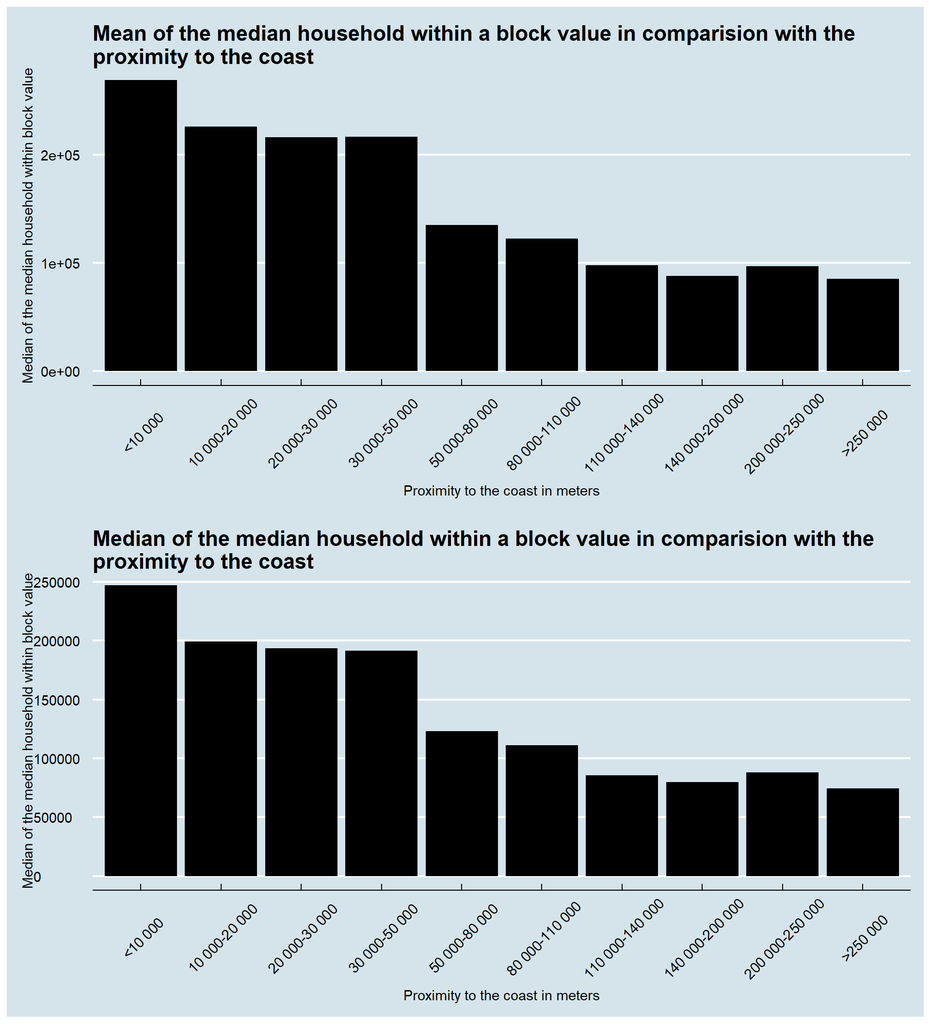

```r
dfHouseAddFeatures%>%
  mutate(proximityToOcean=case_when(Distance_to_coast<10000~"<10 000",
                                    Distance_to_coast<20000~"10 000-20 000",
                                    Distance_to_coast<30000~"20 000-30 000",
                                    Distance_to_coast<50000~"30 000-50 000",
                                    Distance_to_coast<80000~"50 000-80 000",
                                    Distance_to_coast<110000~"80 000-110 000",
                                    Distance_to_coast<140000~"110 000-140 000",
                                    Distance_to_coast<200000~"140 000-200 000",
                                    Distance_to_coast<250000~"200 000-250 000",
                                    TRUE~">250 000"))%>%
  group_by(proximityToOcean)%>%
  summarise(MeanHouseValue=mean(Median_House_Value), MedianHouseValue=median(Median_House_Value))%>%
  arrange(as.integer(proximityToOcean))->dfProximityOcean


dfProximityOcean$proximityToOcean<-factor(dfProximityOcean$proximityToOcean,levels=c("<10 000", "10 000-20 000", "20 000-30 000", "30 000-50 000", "50 000-80 000", "80 000-110 000", "110 000-140 000", "140 000-200 000", "200 000-250 000", ">250 000"))


coastProximityMean<-ggplot(data=dfProximityOcean)+
  geom_col(aes(x = factor(proximityToOcean), y = MeanHouseValue),stat="identity", fill="black")+
  ggthemes::theme_economist()+
  ylab("Median of the median household within block value")+
  xlab("Proximity to the coast in meters")+
  ggtitle("Mean of the median household within a block value in comparision with the\nproximity to the coast")+
  theme(axis.text.x = element_text(angle=45,vjust=0.6))


coastProximityMedian<-ggplot(data=dfProximityOcean)+
  geom_col(aes(x = factor(proximityToOcean), y = MedianHouseValue),stat="identity", fill="black")+
  ggthemes::theme_economist()+
  ylab("Median of the median household within block value")+
  xlab("Proximity to the coast in meters")+
  ggtitle("Median of the median household within a block value in comparision with the\nproximity to the coast")+
  theme(axis.text.x = element_text(angle=45,vjust=0.6))


(coastProximityMean/coastProximityMedian)
```

One of the things missing from the dataset we currently have are the cities and countries from which the data were taken. To add these missing features we will use the tidygeocoder library, which allows us, with the use of latitude and longitude parameters, to trace the exact city where the data was originally taken.

```r
lat_long_to_city<-\(lat, long){
  city<-reverse_geo(lat, long, method = 'arcgis',
            full_results=TRUE, api_options(iq_region="CA"),
            limit = 1)%>%select(15)%>%as.character()
  return(city)
}


dfHouseAddFeatures%>%
  rowwise()%>%
  mutate(city=lat_long_to_city(Latitude, Longitude))->dfHouseCity
```

To further extend this data, we will use another Kraggle dataset called the California cities dataset. Using this dataset, we will trace the country in which a city is located.

```r
dfHouseCity%>%
  inner_join(dfCityCountry, by=c("city"="City"))->dfHouseCityCountry


dfHouseCityCountry%>%
  head()%>%
  DT::datatable(options = list(scrollX = TRUE))
```

|  | Median_House_Value | Median_Income | Median_Age | Tot_Rooms | Tot_Bedrooms | Population | Households | Latitude | Longitude | Distance_to_coast | Distance_to_LA | Distance_to_SanDiego | Distance_to_SanJose | Distance_to_SanFrancisco | num_room_household | num_bedrooms_household | num_population_household | city | County | Incorportation_date | pop_april_1980 | pop_april_1990 | pop_april_2000 | pop_april_2010 |
| --- | --- | --- | --- | --- | --- | --- | --- | --- | --- | --- | --- | --- | --- | --- | --- | --- | --- | --- | --- | --- | --- | --- | --- | --- |
| 1 | 452600 | 8.3252 | 41 | 880 | 129 | 322 | 126 | 37.88 | -122.23 | 9263.04077285038 | 556529.1583418 | 735501.80698384 | 67432.5170008434 | 21250.2137667799 | 6.98412698412698 | 1.02380952380952 | 2.55555555555556 | Berkeley | Alameda | 1878 | 103328 | 102724 | 102743 | 112580 |
| 2 | 358500 | 8.3014 | 21 | 7099 | 1106 | 2401 | 1138 | 37.86 | -122.22 | 10225.7330715424 | 554279.850068765 | 733236.884360166 | 65049.9085739663 | 20880.6003997074 | 6.23813708260105 | 0.971880492091388 | 2.10984182776801 | Oakland | Alameda | 1852 | 339337 | 372242 | 399484 | 390724 |
| 3 | 352100 | 7.2574 | 52 | 1467 | 190 | 496 | 177 | 37.85 | -122.24 | 8259.08510932293 | 554610.717069378 | 733525.68293736 | 64867.2898334847 | 18811.4874496884 | 8.28813559322034 | 1.07344632768362 | 2.80225988700565 | Oakland | Alameda | 1852 | 339337 | 372242 | 399484 | 390724 |
| 4 | 341300 | 5.6431 | 52 | 1274 | 235 | 558 | 219 | 37.85 | -122.25 | 7768.0865708364 | 555194.266086292 | 734095.290744033 | 65287.1384120522 | 18031.0475677266 | 5.81735159817352 | 1.07305936073059 | 2.54794520547945 | Oakland | Alameda | 1852 | 339337 | 372242 | 399484 | 390724 |
| 5 | 342200 | 3.8462 | 52 | 1627 | 280 | 565 | 259 | 37.85 | -122.25 | 7768.0865708364 | 555194.266086292 | 734095.290744033 | 65287.1384120522 | 18031.0475677266 | 6.28185328185328 | 1.08108108108108 | 2.18146718146718 | Oakland | Alameda | 1852 | 339337 | 372242 | 399484 | 390724 |
| 6 | 269700 | 4.0368 | 52 | 919 | 213 | 413 | 193 | 37.85 | -122.25 | 7768.0865708364 | 555194.266086292 | 734095.290744033 | 65287.1384120522 | 18031.0475677266 | 4.76165803108808 | 1.10362694300518 | 2.13989637305699 | Oakland | Alameda | 1852 | 339337 | 372242 | 399484 | 390724 |

Now we can further anylyse the data, and the first step in this direction will be to understand which of the cities had the greater price of the median household price within a block. We can see that the top places are held by places that also today are very rich, like Beverly Hills, La Habra Heights, Los Altos Hills and so on. The main problem in this case, is that we are limited by the top value, that is 500,000 US Dollars.

On the other hand, we can observe the cities that have the lowest median of the median households within a block, which the first place is occupied by Farmersville, Alturas and Taft, which are cities far from the coast and large centers.

```r
dfHouseCityCountry%>%
  group_by(city, pop_april_1990, pop_april_2010, County)%>%
  summarise(MedianPriceHouseCity=median(Median_House_Value))%>%
  arrange(desc(MedianPriceHouseCity))->dfMedianPriceHouses


dfMedianPriceHouses%>%
  DT::datatable(options = list(scrollX = TRUE))
```

|  | city | pop_april_1990 | pop_april_2010 | County | MedianPriceHouseCity |
| --- | --- | --- | --- | --- | --- |
| 1 | Atherton | 7163 | 6914 | San Mateo | 500001 |
| 2 | Beverly Hills | 31971 | 34109 | Los Angeles | 500001 |
| 3 | Del Mar | 4860 | 4161 | San Diego | 500001 |
| 4 | La Habra Heights | 6226 | 5325 | Los Angeles | 500001 |
| 5 | Los Altos | 26303 | 28976 | Santa Clara | 500001 |
| 6 | Los Altos Hills | 7514 | 7922 | Santa Clara | 500001 |
| 7 | Manhattan Beach | 32063 | 35135 | Los Angeles | 500001 |
| 8 | Menlo Park | 28040 | 32026 | San Mateo | 500001 |
| 9 | Newport Beach | 66643 | 85186 | Orange | 500001 |
| 10 | Portola Valley | 4194 | 4353 | San Mateo | 500001 |

[output cut: 419 more lines]

Now we also want to know which countries had a higher median price of the median houshold within a block and which had a lower price. To do this, let’s group the countries this time. This time, the countries on the top are Marin, San Mateo and Santa Clara. Even today these countries are havens where rich people reside. On the other side we have Modoc, Madera and Kings that are rural places with a lower median household value.

```r
dfMedianPriceHouses%>%
  group_by(County)%>%
  dplyr::summarise(MedianPriceHouseCountry=median(MedianPriceHouseCity), Population_April_1990 = sum(pop_april_1990))%>%
  arrange(desc(MedianPriceHouseCountry))%>%
    DT::datatable()
```

|  | County | MedianPriceHouseCountry | Population_April_1990 |
| --- | --- | --- | --- |
| 1 | Marin | 362100 | 156318 |
| 2 | San Mateo | 351000 | 553143 |
| 3 | Santa Clara | 327300 | 1382913 |
| 4 | San Francisco | 327000 | 723959 |
| 5 | Santa Cruz | 253750 | 98925 |
| 6 | Orange | 250000 | 2183131 |
| 7 | Contra Costa | 231100 | 652294 |
| 8 | Ventura | 224450 | 582143 |
| 9 | Alameda | 217900 | 1148698 |
| 10 | Santa Barbara | 214750 | 208471 |

[output cut: 44 more lines]

During the analysis of the correlation headmap presented in the Linear correlation of the data chapter we saw that the Media Age of the household is negatively correlated with the population, household and rooms within a household. Now we want also to see which of the considered cities have the higher median of the median household within a block median age.

```r
dfHouseCityCountry%>%
  group_by(city, pop_april_1990, County)%>%
  summarise(MedianAgeCity=median(Median_Age),MedianHousePrice=median(Median_House_Value))%>%
  arrange(desc(MedianAgeCity))->dfMedianAgeHousehold

dfMedianAgeHousehold%>%
  DT::datatable()
```

|  | city | pop_april_1990 | County | MedianAgeCity | MedianHousePrice |
| --- | --- | --- | --- | --- | --- |
| 1 | Alameda | 76459 | Alameda | 52 | 234250 |
| 2 | Albany | 16327 | Alameda | 52 | 229100 |
| 3 | Avalon | 2918 | Los Angeles | 52 | 357350 |
| 4 | Berkeley | 102724 | Alameda | 52 | 238650 |
| 5 | Emeryville | 5740 | Alameda | 52 | 106400 |
| 6 | Ferndale | 1331 | Humboldt | 52 | 106700 |
| 7 | Ross | 2123 | Marin | 52 | 500001 |
| 8 | San Francisco | 723959 | San Francisco | 52 | 327000 |
| 9 | San Marino | 12959 | Los Angeles | 49 | 500001 |
| 10 | Oakland | 372242 | Alameda | 46 | 140500 |

[output cut: 419 more lines]

The following plot depict the map of California that contain the cities that are colored based on the median of the median age of the household within a block contained in the data set. The cities that have the oldest building are colored in yellow. On the other side the cities with a newer buildings are colored in darker blue.

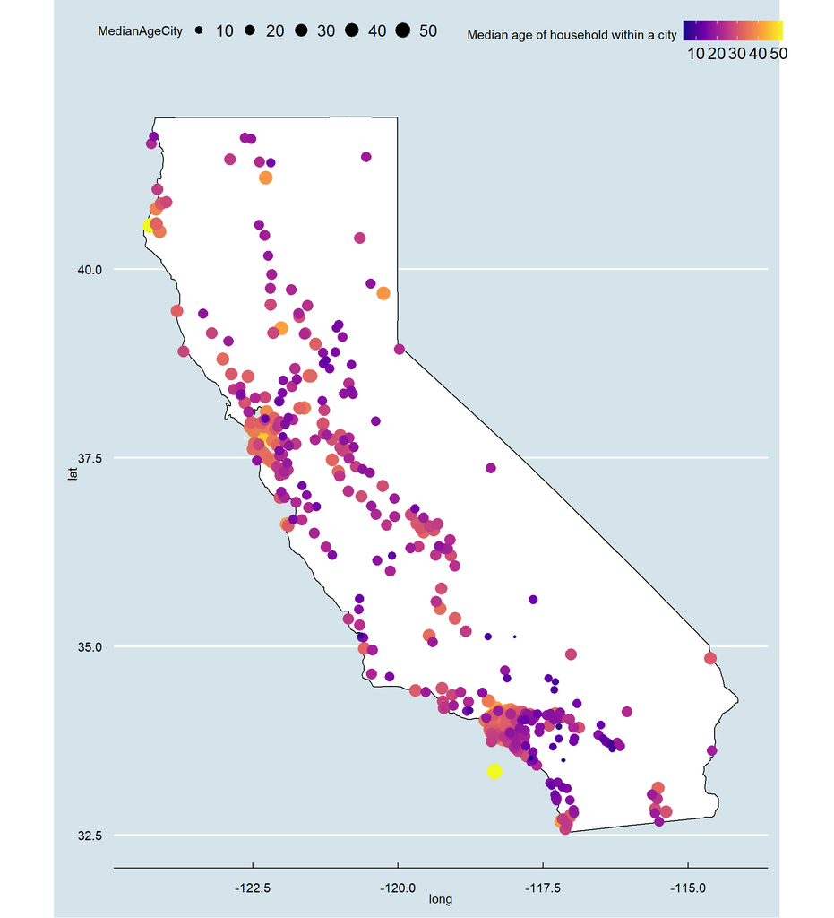

```r
ggplot()+
  geom_polygon(data=west_coast,aes(x = long, y = lat, group = group), fill = "white", color = "black") +
  geom_point(data=dfMedianAgeHousehold%>%inner_join(LatLongCities, by=c("city"="Name")), aes(x = Longitude, y = Latitude, colour = MedianAgeCity, size = MedianAgeCity), shape = "circle")+
  scale_color_viridis_c(option = "plasma", direction = 1) +
  coord_fixed(1.3)+
  labs(color = "Median age of household within a city\n") +
  ggthemes::theme_economist()
```

With the data that we have available, we can also check the demographically grow of each city during two decades.

```r
dfHouseCityCountry%>%
  mutate(Percent_Change_Population = ((pop_april_2010 - pop_april_1990)/pop_april_1990))%>%
  group_by(city, pop_april_1990, pop_april_2010)%>%
  summarise(Percent_Change=mean(Percent_Change_Population))%>%
  arrange(desc(Percent_Change))->PercentageChangePop

datatable(PercentageChangePop)%>%
  formatPercentage('Percent_Change', 2)
```

|  | city | pop_april_1990 | pop_april_2010 | Percent_Change |
| --- | --- | --- | --- | --- |
| 1 | Brentwood | 7563 | 51481 | 5.80695491207193 |
| 2 | Lincoln | 7248 | 42819 | 4.90769867549669 |
| 3 | Chula Vista | 63126 | 243916 | 2.8639546304217 |
| 4 | Beaumont | 9685 | 36877 | 2.80764068146618 |
| 5 | Adelanto | 8517 | 31765 | 2.72959962428085 |
| 6 | Temecula | 27099 | 100097 | 2.69375253699399 |
| 7 | Soledad | 7146 | 25738 | 2.60173523649594 |
| 8 | Imperial | 4113 | 14758 | 2.58813518113299 |
| 9 | La Quinta | 11215 | 37467 | 2.34079358002675 |
| 10 | Perris | 21460 | 68386 | 2.18667287977633 |

[output cut: 419 more lines]

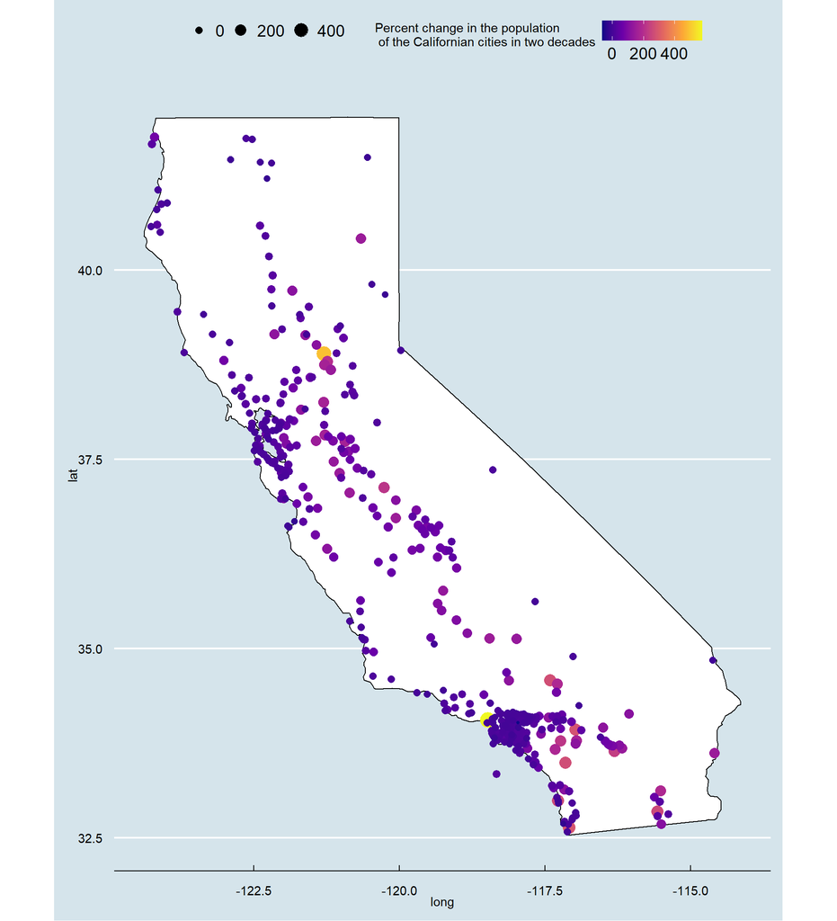

```r
ggplot()+
  geom_polygon(data=west_coast,aes(x = long, y = lat, group = group), fill = "white", color = "black") +
  geom_point(data=PercentageChangePop%>%
               inner_join(LatLongCities, by=c("city"="Name"))%>%
               mutate(PercentChangeP=Percent_Change*100),
             aes(x = Longitude, y = Latitude, colour = PercentChangeP, size = PercentChangeP),
             shape = "circle")+
  scale_color_viridis_c(option = "plasma", direction = 1) +
  coord_fixed(1.3)+
  labs(size="", color = "Percent change in the population\n of the Californian cities in two decades\n") +
  ggthemes::theme_economist()
```

## Conclusion

In this project we analysed the dataset “California Housing Prices” with scatter, correlation, density, bar plots and other analysis techniques. The median income for household within a block is positively correlated with the median house price within a block. On the other side, the distance to coast is negatively correlated. This two features represent the higher correlation with the median value for household within a block, and with this we can answer to our first research question.

With the Pearson correlation we saw some interesting linear correlation between different features. One of this is the median age of the household within a block is negatively correlated with the total number of rooms, total number of bedrooms, population and household within a block.

Using the data regarding the distance to coast, we discretised the proximity to the ocean in different bins, that allowed us to check how the proximity to the coast influence the median and mean of the median House Value. We founded out that in this case the nearest is the house to the ocean, the greater is also the value. Obviously, this can be also influenced by the biggest Californian cities that are all coastal. With this we can also answer the third research question.

After that, we added to our data set the city in which the data was gathered using the latitude and longitude coordinates. This allowed us to study in which cities and countries have the greater median household price, and which the lowest. The highest podium, in the case of the cities, we found Bevery Hills, Los Altos Hills, Newport Beach and so on that also today are know as the places where expensive houses are build. In the case of the countries with the highest median of the median household within a block value are Marin, San Mateo, Santa Clara, San Francisco and so on. On the other hand the lowest placed cities are Farmersville, Alturas and Taft, and the lowest placed countries are Modoc, Maera and Kings, that are rural places far from big centers. With this we can also answer the second research question.

Finally, we drew several geographic maps showing the average age of households in each Californian city. Another interesting graph focused on the population growth of each city in the State of California over a 20-year period.

## Literature

FEDESORIANO. 2022. “California Housing Prices Data (5 New Features!).” https://www.kaggle.com/datasets/fedesoriano/california-housing-prices-data-extra-features.

Géron, Aurélien, and Rebecca Demarest. 2019. *Hands-on Machine Learning with Scikit-Learn and Tensorflow: Concepts, Tools, and Techniques to Build Intelligent Systems*. O’Reilly.

NUGENT, CAM. 2019. “California Cities Dataset.” https://www.kaggle.com/datasets/camnugent/california-housing-feature-engineering.

Pace, Kelley, and Ronald Barry. 1997. “Sparse Spatial Autoregressions.” *Statistics & Probability Letters* 33 (3): 291–97. [https://EconPapers.repec.org/RePEc:eee:stapro:v:33:y:1997:i:3:p:291-297](https://econpapers.repec.org/RePEc:eee:stapro:v:33:y:1997:i:3:p:291-297).